# Homework 3

PSTAT 131/231

```r
library(tidyverse)
library(tidymodels)
library(corrplot)
library(discrim)
library(poissonreg)
library(corrr)
library(klaR) # for naive bayes
tidymodels_prefer()
```

```r
df_titanic <- read.csv("data/titanic.csv")
summary(df_titanic)
```

```
##   passenger_id     survived             pclass          name
##  Min.   :  1.0   Length:891         Min.   :1.000   Length:891
##  1st Qu.:223.5   Class :character   1st Qu.:2.000   Class :character
##  Median :446.0   Mode  :character   Median :3.000   Mode  :character
##  Mean   :446.0                      Mean   :2.309
##  3rd Qu.:668.5                      3rd Qu.:3.000
##  Max.   :891.0                      Max.   :3.000
##
##      sex                 age            sib_sp          parch
##  Length:891         Min.   : 0.42   Min.   :0.000   Min.   :0.0000
##  Class :character   1st Qu.:20.12   1st Qu.:0.000   1st Qu.:0.0000
##  Mode  :character   Median :28.00   Median :0.000   Median :0.0000
##                     Mean   :29.70   Mean   :0.523   Mean   :0.3816
##                     3rd Qu.:38.00   3rd Qu.:1.000   3rd Qu.:0.0000
##                     Max.   :80.00   Max.   :8.000   Max.   :6.0000
##                     NA's   :177
##     ticket               fare           cabin             embarked
##  Length:891         Min.   :  0.00   Length:891         Length:891
##  Class :character   1st Qu.:  7.91   Class :character   Class :character
##  Mode  :character   Median : 14.45   Mode  :character   Mode  :character
##                     Mean   : 32.20
##                     3rd Qu.: 31.00
##                     Max.   :512.33
##
```

```r
# Factorization and relevel
df_titanic <- df_titanic %>%
  mutate(pclass = factor(pclass), survived = factor(survived)) %>%
  mutate(survived = fct_relevel(survived, c("Yes", "No")))

levels(df_titanic$pclass)
```

```
## [1] "1" "2" "3"
```

```r
levels(df_titanic$survived)
```

```
## [1] "Yes" "No"
```

# Q1 Data splitting

```r
set.seed(256)
titanic_split <- initial_split(df_titanic, prop = 0.7, strata = survived)
titanic_train <- training(titanic_split)
titanic_testing <- testing(titanic_split)

# Missing data
colnames(df_titanic)[colSums(is.na(df_titanic)) > 0]
```

```
## [1] "age"      "cabin"    "embarked"
```

- Age and Cabin and Embarked columns have missing data
- Use stratified sampling to make sure even representation of subgroups

# Q2

```r
head(titanic_train)
```

```
##    passenger_id survived pclass                                 name    sex age
## 1             1       No      3              Braund, Mr. Owen Harris   male  22
## 5             5       No      3             Allen, Mr. William Henry   male  35
## 7             7       No      1              McCarthy, Mr. Timothy J   male  54
## 8             8       No      3       Palsson, Master. Gosta Leonard   male   2
## 14           14       No      3          Andersson, Mr. Anders Johan   male  39
## 15           15       No      3 Vestrom, Miss. Hulda Amanda Adolfina female  14
##    sib_sp parch    ticket    fare cabin embarked
## 1       1     0 A/5 21171  7.2500  <NA>        S
## 5       0     0    373450  8.0500  <NA>        S
## 7       0     0     17463 51.8625   E46        S
## 8       3     1    349909 21.0750  <NA>        S
## 14      1     5    347082 31.2750  <NA>        S
## 15      0     0    350406  7.8542  <NA>        S
```

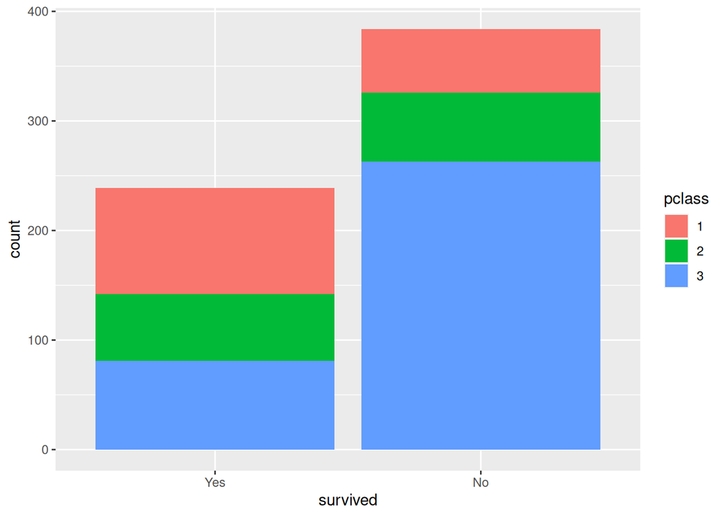

```r
titanic_train %>%
  ggplot(aes(x = survived, fill = pclass)) +
  geom_bar()
```

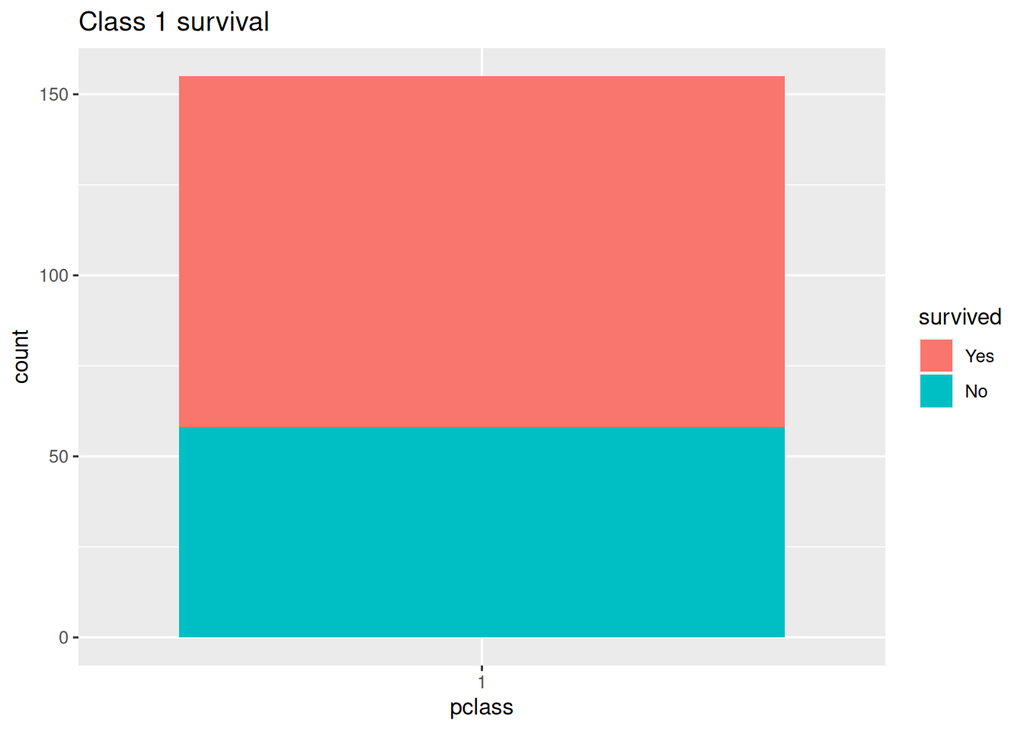

```r
titanic_train %>%
  filter(pclass == "1") %>%
  ggplot(aes(x = pclass, fill = survived)) +
  geom_bar() +
  ggtitle("Class 1 survival")
```

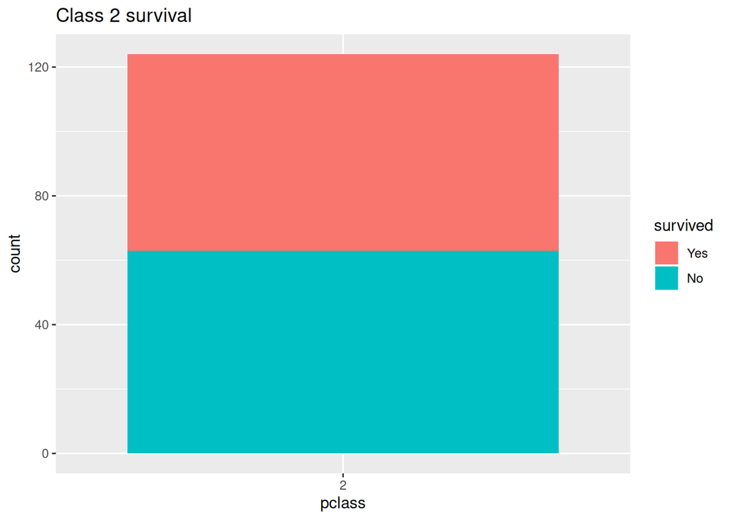

```r
titanic_train %>%
  filter(pclass == "2") %>%
  ggplot(aes(x = pclass, fill = survived)) +
  geom_bar() +
  ggtitle("Class 2 survival")
```

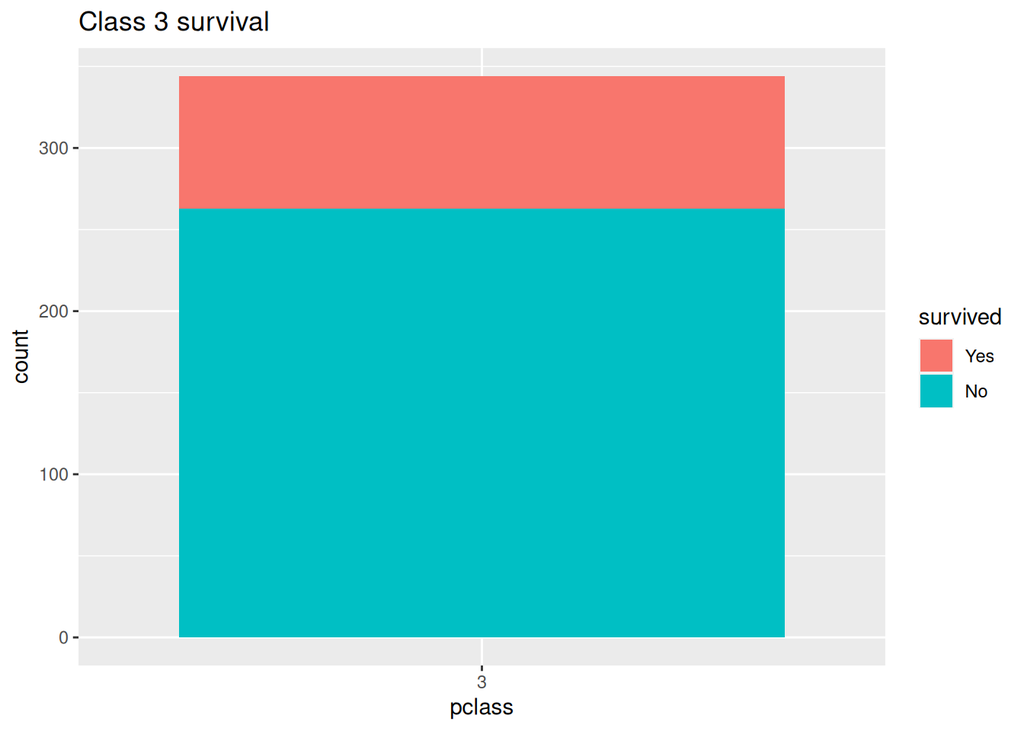

```r
titanic_train %>%
  filter(pclass == "3") %>%
  ggplot(aes(x = pclass, fill = survived)) +
  geom_bar() +
  ggtitle("Class 3 survival")
```

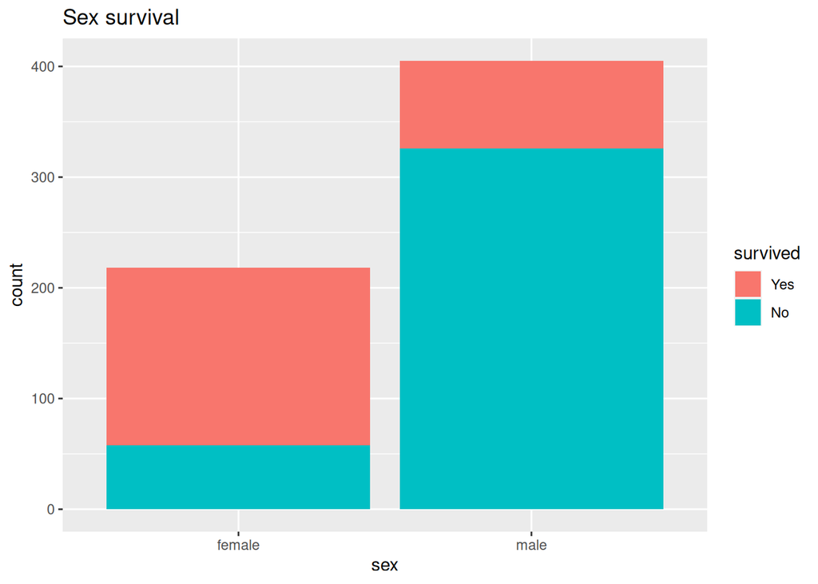

```r
titanic_train %>%
  ggplot(aes(x = sex, fill = survived)) +
  geom_bar() +
  ggtitle("Sex survival")
```

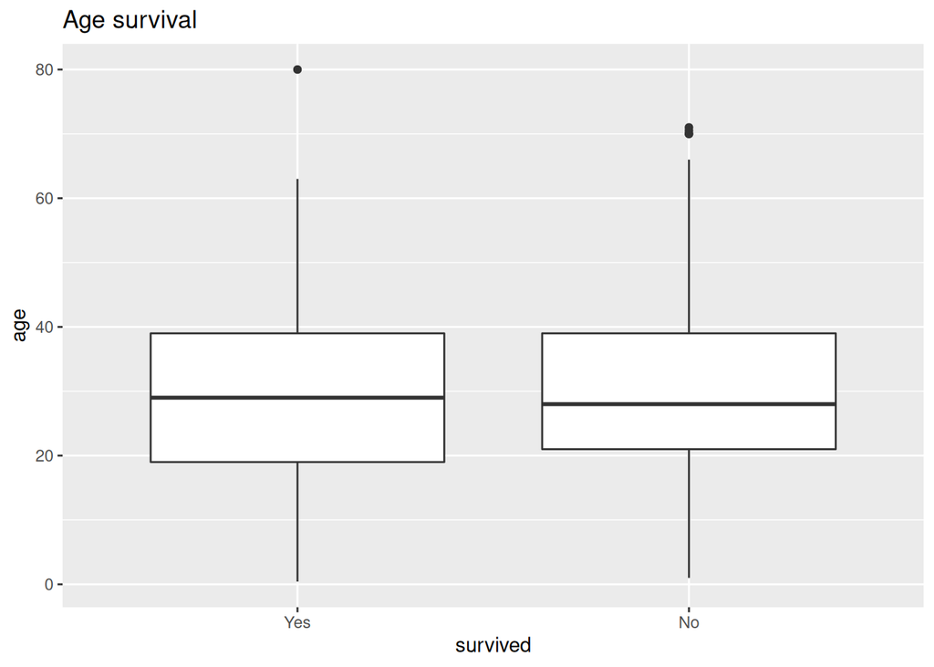

```r
titanic_train %>%
  ggplot(aes(x = survived, y = age)) +
  geom_boxplot() +
  ggtitle("Age survival")
```

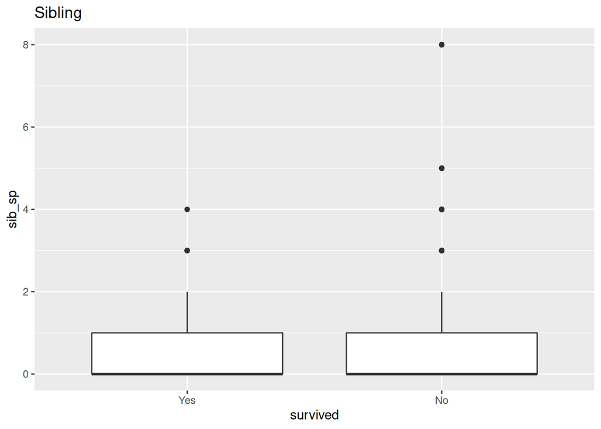

```r
titanic_train %>%
  ggplot(aes(x = survived, y = sib_sp)) +
  geom_boxplot() +
  ggtitle("Sibling")
```

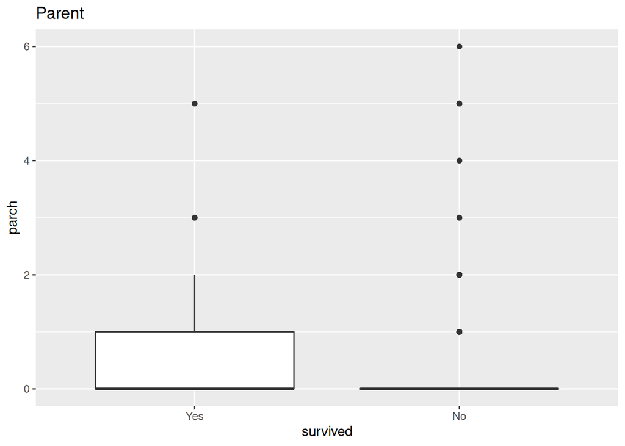

```r
titanic_train %>%
  ggplot(aes(x = survived, y = parch)) +
  geom_boxplot() +
  ggtitle("Parent")
```

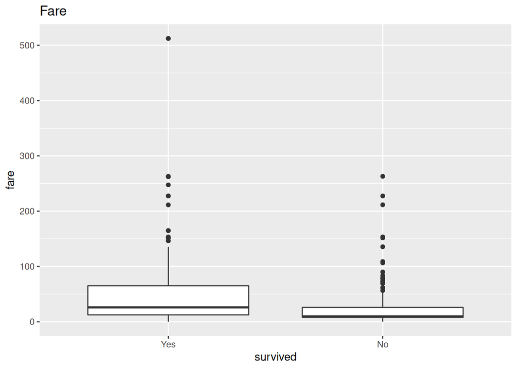

```r
titanic_train %>%
  ggplot(aes(x = survived, y = fare)) +
  geom_boxplot() +
  ggtitle("Fare")
```

- Passagers in class 1 have the highest survival rate, then the class 2 and class 3 has the lowest survival rate
- Female has higher survival rate than male
- The distribution of survived and not survived are very similar if grouped by on age
- Most passager has 0 Siblings or Parents, so it can hardly be used to infer survival rate
- The top 1/4 percentile of survived had payed a higher fare than the top 1/4 perceptile of non-survived

# Q3

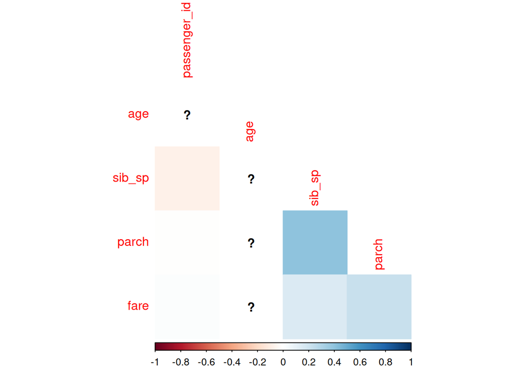

```r
titanic_train %>%
  select(is.numeric) %>%
  cor() %>%
  corrplot(type = "lower", diag = FALSE, method = "color")
```

- Sibling and parch, parch and fare, are pairs that has small positive correlation

# Q4

```r
cleaned_train <- titanic_train %>%
  select(-c(passenger_id, name, cabin, ticket, embarked))

recipe <- recipe(survived ~ ., data = cleaned_train) %>%
  step_dummy(all_nominal_predictors()) %>%
  step_interact(terms = ~ starts_with("sex"):fare) %>%
  step_interact(terms = ~ starts_with("pclass"):fare) %>%
  step_normalize(all_numeric_predictors()) %>%
  step_impute_linear(age, impute_with = imp_vars(all_predictors()))
recipe
```

```
## Recipe
##
## Inputs:
##
##       role #variables
##    outcome          1
##  predictor          6
##
## Operations:
##
## Dummy variables from all_nominal_predictors()
## Interactions with starts_with("sex"):fare
## Interactions with starts_with("pclass"):fare
## Centering and scaling for all_numeric_predictors()
## Linear regression imputation for age
```

# Q5

```r
log_reg <- logistic_reg() %>%
  set_engine("glm") %>%
  set_mode("classification")

log_workflow <- workflow() %>%
  add_model(log_reg) %>%
  add_recipe(recipe = recipe)
```

```r
log_fit <- fit(log_workflow, cleaned_train)
log_fit %>%
  tidy()
```

```
## # A tibble: 11 × 5
##    term             estimate std.error statistic  p.value
##    <chr>               <dbl>     <dbl>     <dbl>    <dbl>
##  1 (Intercept)         0.579     0.130      4.45 8.75e- 6
##  2 age                 0.603     0.143      4.22 2.48e- 5
##  3 sib_sp              0.560     0.163      3.44 5.80e- 4
##  4 parch               0.136     0.122      1.12 2.63e- 1
##  5 fare               -0.658     0.434     -1.52 1.30e- 1
##  6 pclass_X2           0.566     0.211      2.68 7.37e- 3
##  7 pclass_X3           1.22      0.231      5.29 1.24e- 7
##  8 sex_male            1.17      0.151      7.76 8.17e-15
##  9 sex_male_x_fare     0.345     0.293      1.18 2.39e- 1
## 10 pclass_X2_x_fare   -0.222     0.174     -1.27 2.04e- 1
## 11 pclass_X3_x_fare   -0.199     0.196     -1.01 3.11e- 1
```

# Q6

```r
lda_mod <- discrim_linear() %>%
  set_mode("classification") %>%
  set_engine("MASS")

lda_workflow <- workflow() %>%
  add_model(lda_mod) %>%
  add_recipe(recipe = recipe)

lda_fit <- fit(lda_workflow, cleaned_train)
lda_fit
```

```
## ══ Workflow [trained] ══════════════════════════════════════════════════════════
## Preprocessor: Recipe
## Model: discrim_linear()
##
## ── Preprocessor ────────────────────────────────────────────────────────────────
## 5 Recipe Steps
##
## • step_dummy()
## • step_interact()
## • step_interact()
## • step_normalize()
## • step_impute_linear()
##
## ── Model ───────────────────────────────────────────────────────────────────────
## Call:
## lda(..y ~ ., data = data)
##
## Prior probabilities of groups:
##       Yes        No
## 0.3836276 0.6163724
##
## Group means:
##             age      sib_sp       parch       fare   pclass_X2  pclass_X3
## Yes -0.05938185 -0.02012914  0.11576350  0.3655425  0.14062480 -0.4285058
## No   0.01287639  0.01252829 -0.07205072 -0.2275121 -0.08752429  0.2667002
##       sex_male sex_male_x_fare pclass_X2_x_fare pclass_X3_x_fare
## Yes -0.6694277     -0.07316167        0.1613671       -0.2489253
## No   0.4166490      0.04553552       -0.1004342        0.1549301
##
## Coefficients of linear discriminants:
##                          LD1
## age               0.37437710
## sib_sp            0.29794841
## parch             0.08354210
## fare             -0.08939429
## pclass_X2         0.40849958
## pclass_X3         0.82751553
## sex_male          1.01006321
## sex_male_x_fare  -0.03177390
## pclass_X2_x_fare -0.16394463
## pclass_X3_x_fare -0.10456501
```

# Q7

```r
qda_mod <- discrim_linear() %>%
  set_mode("classification") %>%
  set_engine("MASS")

qda_workflow <- workflow() %>%
  add_model(qda_mod) %>%
  add_recipe(recipe = recipe)

qda_fit <- fit(qda_workflow, cleaned_train)
qda_fit
```

```
## ══ Workflow [trained] ══════════════════════════════════════════════════════════
## Preprocessor: Recipe
## Model: discrim_linear()
##
## ── Preprocessor ────────────────────────────────────────────────────────────────
## 5 Recipe Steps
##
## • step_dummy()
## • step_interact()
## • step_interact()
## • step_normalize()
## • step_impute_linear()
##
## ── Model ───────────────────────────────────────────────────────────────────────
## Call:
## lda(..y ~ ., data = data)
##
## Prior probabilities of groups:
##       Yes        No
## 0.3836276 0.6163724
##
## Group means:
##             age      sib_sp       parch       fare   pclass_X2  pclass_X3
## Yes -0.05938185 -0.02012914  0.11576350  0.3655425  0.14062480 -0.4285058
## No   0.01287639  0.01252829 -0.07205072 -0.2275121 -0.08752429  0.2667002
##       sex_male sex_male_x_fare pclass_X2_x_fare pclass_X3_x_fare
## Yes -0.6694277     -0.07316167        0.1613671       -0.2489253
## No   0.4166490      0.04553552       -0.1004342        0.1549301
##
## Coefficients of linear discriminants:
##                          LD1
## age               0.37437710
## sib_sp            0.29794841
## parch             0.08354210
## fare             -0.08939429
## pclass_X2         0.40849958
## pclass_X3         0.82751553
## sex_male          1.01006321
## sex_male_x_fare  -0.03177390
## pclass_X2_x_fare -0.16394463
## pclass_X3_x_fare -0.10456501
```

# Q8

```r
nb_mod <- naive_Bayes() %>%
  set_mode("classification") %>%
  set_engine("klaR") %>%
  set_args(usekernel = FALSE)

nb_workflow <- workflow() %>%
  add_model(nb_mod) %>%
  add_recipe(recipe = recipe)

nb_fit <- fit(nb_workflow, cleaned_train)
nb_fit
```

```
## ══ Workflow [trained] ══════════════════════════════════════════════════════════
## Preprocessor: Recipe
## Model: naive_Bayes()
##
## ── Preprocessor ────────────────────────────────────────────────────────────────
## 5 Recipe Steps
##
## • step_dummy()
## • step_interact()
## • step_interact()
## • step_normalize()
## • step_impute_linear()
##
## ── Model ───────────────────────────────────────────────────────────────────────
## $apriori
## grouping
##       Yes        No
## 0.3836276 0.6163724
##
## $tables
## $tables$age
##            [,1]      [,2]
## Yes -0.05938185 0.9733417
## No   0.01287639 0.8965625
##
## $tables$sib_sp
##            [,1]      [,2]
## Yes -0.02012914 0.6569326
## No   0.01252829 1.1642314
##
## $tables$parch
##            [,1]      [,2]
## Yes  0.11576350 0.9530082
## No  -0.07205072 1.0227774
##
## $tables$fare
##           [,1]      [,2]
## Yes  0.3655425 1.3627973
## No  -0.2275121 0.5784883
##
```

[output cut: 12 more lines]

```
## Yes -0.6694277 0.9875738
## No   0.4166490 0.7511752
##
## $tables$sex_male_x_fare
##            [,1]      [,2]
## Yes -0.07316167 1.2200762
## No   0.04553552 0.8328144
##
## $tables$pclass_X2_x_fare
##           [,1]      [,2]
## Yes  0.1613671 1.1311002
## No  -0.1004342 0.8958986
##
## ...
## and 1273 more lines.
```

# 9 Assessing the accurancy

```r
log_pred <- predict(log_fit, new_data = cleaned_train, type="prob")
augment(log_fit, new_data = cleaned_train) %>%
  conf_mat(truth=survived, estimate = .pred_class)
```

```
##           Truth
## Prediction Yes  No
##        Yes 166  48
##        No   73 336
```

```r
log_reg_acc <- augment(log_fit, new_data = cleaned_train) %>%
  accuracy(truth=survived, estimate = .pred_class)

lda_pred <- predict(lda_fit, new_data = cleaned_train, type="prob")
augment(lda_fit, new_data = cleaned_train) %>%
  conf_mat(truth=survived, estimate = .pred_class)
```

```
##           Truth
## Prediction Yes  No
##        Yes 167  53
##        No   72 331
```

```r
lda_acc <- augment(lda_fit, new_data = cleaned_train) %>%
  accuracy(truth=survived, estimate = .pred_class)


qda_pred <- predict(qda_fit, new_data = cleaned_train, type="prob")
augment(qda_fit, new_data = cleaned_train) %>%
  conf_mat(truth=survived, estimate = .pred_class)
```

```
##           Truth
## Prediction Yes  No
##        Yes 167  53
##        No   72 331
```

```r
qda_acc <- augment(qda_fit, new_data = cleaned_train) %>%
  accuracy(truth=survived, estimate = .pred_class)

nb_pred <- predict(nb_fit, new_data = cleaned_train, type="prob")
augment(nb_fit, new_data = cleaned_train) %>%
  conf_mat(truth=survived, estimate = .pred_class)
```

```
##           Truth
## Prediction Yes  No
##        Yes 132  42
##        No  107 342
```

```r
nb_acc <- augment(nb_fit, new_data = cleaned_train) %>%
  accuracy(truth=survived, estimate = .pred_class)

log_pred
```

```
## # A tibble: 623 × 2
##    .pred_Yes .pred_No
##        <dbl>    <dbl>
##  1    0.0779    0.922
##  2    0.0803    0.920
##  3    0.317     0.683
##  4    0.0683    0.932
##  5    0.0299    0.970
##  6    0.722     0.278
##  7    0.283     0.717
##  8    0.454     0.546
##  9    0.102     0.898
## 10    0.0703    0.930
## # … with 613 more rows
```

```r
train_with_pred <- bind_cols(cleaned_train, log_pred, lda_pred, qda_pred, nb_pred)
head(train_with_pred)
```

```
##   survived pclass    sex age sib_sp parch    fare .pred_Yes...8 .pred_No...9
## 1       No      3   male  22      1     0  7.2500    0.07785699    0.9221430
## 2       No      3   male  35      0     0  8.0500    0.08027483    0.9197252
## 3       No      1   male  54      0     0 51.8625    0.31672660    0.6832734
## 4       No      3   male   2      3     1 21.0750    0.06828501    0.9317150
## 5       No      3   male  39      1     5 31.2750    0.02994639    0.9700536
## 6       No      3 female  14      0     0  7.8542    0.72201375    0.2779863
##   .pred_Yes...10 .pred_No...11 .pred_Yes...12 .pred_No...13 .pred_Yes...14
## 1     0.04955239     0.9504476     0.04955239     0.9504476   0.0225564772
## 2     0.04736516     0.9526348     0.04736516     0.9526348   0.0208795994
## 3     0.27235833     0.7276417     0.27235833     0.7276417   0.2827391452
## 4     0.04930976     0.9506902     0.04930976     0.9506902   0.0001497699
## 5     0.01775856     0.9822414     0.01775856     0.9822414   0.0008988965
## 6     0.79470279     0.2052972     0.79470279     0.2052972   0.4870265191
##   .pred_No...15
## 1     0.9774435
## 2     0.9791204
## 3     0.7172609
## 4     0.9998502
## 5     0.9991011
## 6     0.5129735
```

```r
accuracies <- c(log_reg_acc$.estimate, lda_acc$.estimate, nb_acc$.estimate, qda_acc$.estimate)
models <- c("Logistic Regression", "LDA", "Naive Bayes", "QDA")
results <- tibble(accuracies = accuracies, models = models)
results %>%
  arrange(-accuracies)
```

```
## # A tibble: 4 × 2
##   accuracies models
##        <dbl> <chr>
## 1      0.806 Logistic Regression
## 2      0.799 LDA
## 3      0.799 QDA
## 4      0.761 Naive Bayes
```

- choose logistic regression for the highest accuracies

# Q10

```r
predict(log_fit, new_data = titanic_testing, type="prob")
```

```
## # A tibble: 268 × 2
##    .pred_Yes .pred_No
##        <dbl>    <dbl>
##  1    0.930    0.0698
##  2    0.922    0.0782
##  3    0.103    0.897
##  4    0.905    0.0952
##  5    0.139    0.861
##  6    0.0481   0.952
##  7    0.509    0.491
##  8    0.101    0.899
##  9    0.347    0.653
## 10    0.432    0.568
## # … with 258 more rows
```

```r
augment(log_fit, new_data = titanic_testing) %>%
  conf_mat(truth = survived, estimate = .pred_class)
```

```
##           Truth
## Prediction Yes  No
##        Yes  73  22
##        No   30 143
```

```r
multi_metric <- metric_set(accuracy, sensitivity, specificity)

augment(log_fit, new_data = titanic_testing) %>%
  multi_metric(truth = survived, estimate = .pred_class)
```

```
## # A tibble: 3 × 3
##   .metric     .estimator .estimate
##   <chr>       <chr>          <dbl>
## 1 accuracy    binary         0.806
## 2 sensitivity binary         0.709
## 3 specificity binary         0.867
```

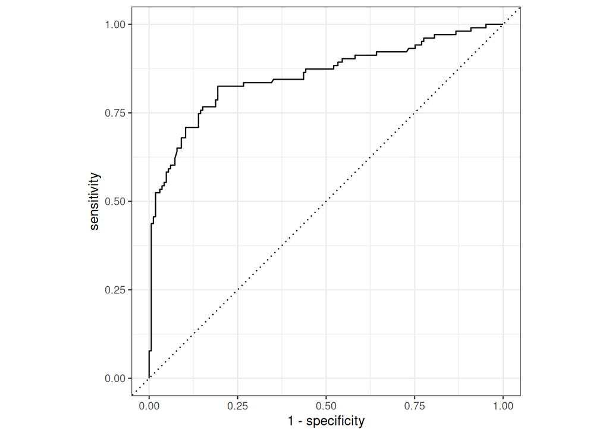

```r
augment(log_fit, new_data = titanic_testing) %>%
  roc_curve(survived, .pred_Yes) %>%
  autoplot()
```

# Q11

$$\begin{eqnarray}
p(z) = p &=& \frac{e^z}{1+e^z} \\
pe^z + p &=& e^z \\
p &=& (1-p)e^z \\
\frac{p}{1-p} &=& e^z \\
z &=& ln(\frac{p}{1-p})
\end{eqnarray}$$

# Q12

$$\begin{eqnarray}
z = \beta_0 +\beta_1(x_1+2) &=& ln(\frac{p}{1-p}) \\
\beta_0 +\beta_1x_1 +2\beta_1 &=& ln(\frac{p}{1-p}) \\
e^{\beta_0 +\beta_1x_1 +2\beta_1} &=& \frac{p}{1-p} \\
e^{2\beta_1}e^{\beta_0 +\beta_1x_1} &=& \frac{p}{1-p}
\end{eqnarray}$$

The odd increases by $e^{2\beta_1}$ if $\beta_1 < 0$
$$\lim_{x_1\rightarrow \infty} e^{\beta_0 +\beta_1x_1} = 0$$

$$\begin{eqnarray}
\frac{p}{1-p} &=& 0 \\
p &=& 0
\end{eqnarray}$$

if $\beta_1 > 0$
$$\begin{eqnarray}
\frac{p}{1-p} &=& \infty \\
p &=& 1
\end{eqnarray}$$